# Introduction

Preprocessing for Multivariate Event Time Series analysis (METS) clustering after [Javed et al., 2020](https://doi.org/10.1016/j.jhydrol.2020.125802).

The preprocessing procedure has been implemented with the instructions provided in [Javed et al., 2020](https://doi.org/10.1016/j.jhydrol.2020.125802). Some adaptations have been made to the filter settings. A demonstration of the implementation is found below, followed by a section describing it and any adaptations made.

## Setup

```python
# modules
from pathlib import Path

import matplotlib.pyplot as plt
import numpy as np
import pandas as pd
import scipy

import hysevt.events.metrics
import hysevt.utils.visualise
import hysevt.events.METS_preprocessing
```

```python
# set base directory
baseDIR = Path("..").resolve()
assert baseDIR.is_dir()

# data directory
dataDIR = baseDIR.joinpath("data")
assert dataDIR.is_dir()

# station
station_id = 201350  # station id for Vent-Rofental gauging station, as used by HD Tirol
station_name = "vent"
events_version = "automatic_local_minimum_events"

# events directory
eventsDIR = dataDIR.joinpath("events_database",station_name , events_version)
assert eventsDIR.is_dir()
```

# DEMO: Preprocess events

First, get the timeseries of suspended sediment and streamflow from the gauge.

```python
# files
file_data = dataDIR.joinpath(
    "preprocessed", f"{station_id}_{station_name}_SSC_Q.csv"
)

# data
gauge_data = hysevt.events.metrics.get_gauge_data(file_data)
```

Next, import the list of events, i.e. a dataframe with event start and end timestamps. To make this clear, I simply use the two first columns of the `event_metrics`-dataframe, and call it `event_list`.

```python
# import dataframe with event start and end timestamps
event_list = pd.read_csv(
    eventsDIR.joinpath(f"events_list_{station_name}.csv"),
    index_col=0,
)
event_list.head()
```

| event_id | start | end |
| --- | --- | --- |
| VEN-AUT-2006-001 | 2006-05-18 08:45:00 | 2006-05-19 09:45:00 |
| VEN-AUT-2006-002 | 2006-05-28 10:15:00 | 2006-06-05 09:30:00 |
| VEN-AUT-2006-003 | 2006-06-13 09:00:00 | 2006-06-14 08:45:00 |
| VEN-AUT-2006-004 | 2006-06-14 09:00:00 | 2006-06-15 09:30:00 |
| VEN-AUT-2006-005 | 2006-06-15 09:45:00 | 2006-06-16 09:00:00 |

Using the list of events and the gauging station data, the timeseries of each event is extracted and saved in a list (`unprocessed_events`). This list is then passed to the `preprocess_all_events` function from the `hysevt.events.METS_preprocessing` module, which returns a 3-dimensional numpy array of the shape (number of events, variables in each timeseries, length of preprocessed timeseries).

This array is now ready to be passed to the Kmedoids-clustering function. As this will be done in a separate script, the array is saved as a `.npy` file.

```python
# extract event series from all events to list
unprocessed_events = [hysevt.events.metrics.get_event_data(event.start, event.end, gauge_data).dropna() for i, event in event_list.iterrows()]
# preprocess data for all events and stack to array
preprocessed_data = hysevt.events.METS_preprocessing.preprocess_all_events(unprocessed_events)

# check that there are no Nans present
assert(np.logical_not(np.isnan(preprocessed_data).any()))

# save to file
np.save(
    eventsDIR.joinpath(
        f"{station_id}_{station_name}_preprocessed_events_for_METS_clustering.npy"
    ),
    preprocessed_data,
)
```

# Description and testing of preprocessing

Here follows a description of the preprocessing procedure. Any deviations from [Javed et al., 2020](https://doi.org/10.1016/j.jhydrol.2020.125802) is indicated. The same settings were used for preprocessing the suspended sediment and streamflow timeseries for all events.

## Test event

```python
test_events = event_list.sample(20)
```

```python
event = test_events.sample(1).iloc[0, :]
event_data = hysevt.events.metrics.get_event_data(
    event.start, event.end, gauge_data
)
```

| time | streamflow | suspended_sediment |
| --- | --- | --- |
| 2020-09-04 08:30:00 | 4.61 | 584.3248 |
| 2020-09-04 08:45:00 | 4.61 | 607.1993 |
| 2020-09-04 09:00:00 | 4.61 | 589.5386 |
| 2020-09-04 09:15:00 | 4.61 | 559.5457 |
| 2020-09-04 09:30:00 | 4.60 | 608.7026 |

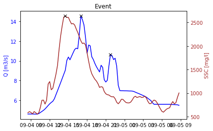

```python
hysevt.utils.visualise.plotEventSeries(event_data)
event_data.head()
```

## Smoothing

A Savitsky-Golay Filter filter is applied to the timeseries. [Javed et al., 2020](https://doi.org/10.1016/j.jhydrol.2020.125802) used different values for the *length of the filter window* `window_length` and the *order of the polynomial* `polyorder` for the larger catchments and the sub-catchments. Each of these were tested for the example events.

I used the existing `scipy.signal.savgol_filter` function for the filtering. The `mode` was set to nearest, which simply extends the edges of the timeseries (i.e. backfill/frontfill). This was done to prevent, wierd edge effects.

```python
help(scipy.signal.savgol_filter)
```

[output not shown]

[output cut: 44 more lines]

```
    >>> x = np.array([2, 2, 5, 2, 1, 0, 1, 4, 9])

    Filter with a window length of 5 and a degree 2 polynomial.  Use
    the defaults for all other parameters.

    >>> savgol_filter(x, 5, 2)
    array([1.66, 3.17, 3.54, 2.86, 0.66, 0.17, 1.  , 4.  , 9.  ])

    Note that the last five values in x are samples of a parabola, so
    when mode='interp' (the default) is used with polyorder=2, the last
    three values are unchanged. Compare that to, for example,
    `mode='nearest'`:

    >>> savgol_filter(x, 5, 2, mode='nearest')
    array([1.74, 3.03, 3.54, 2.86, 0.66, 0.17, 1.  , 4.6 , 7.97])
```

### Testing smoothing on selected catchments

```python
def test_smoothing(test_events, window_length, polyorder,data = gauge_data):
    for i, event in test_events.iterrows():
        event_data = hysevt.events.metrics.get_event_data(
            event.start, event.end, data
        )

        q = event_data.streamflow.values
        s = event_data.suspended_sediment.values
        try:
            q_smooth = scipy.signal.savgol_filter(q, window_length, polyorder,mode="nearest")
            s_smooth = scipy.signal.savgol_filter(s, window_length, polyorder,mode="nearest")
        except ValueError as e:
            print(f"Event no. {i}:  {len(q)} timesteps")
            print(e)
            print("-" * 100)
            continue

        fig, ax = plt.subplots(ncols=2,figsize=(7,2))
        ax[0].plot(q, label="original")
        ax[0].plot(q_smooth, label="smoothed")
        ax[0].set_title("Streamflow")
        ax[0].legend()
        ax[1].plot(s)
        ax[1].plot(s_smooth)
        ax[1].set_title("Suspended sediment")
        fig.suptitle(f"Event no. {i}")
```

#### Filter settings 1 from Javed et al.

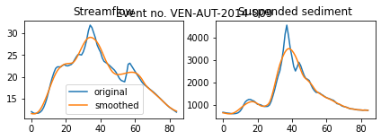

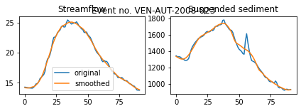

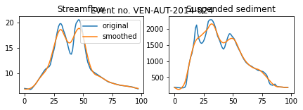

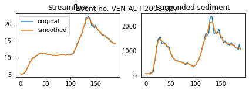

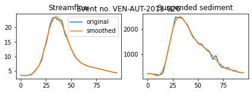

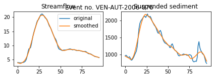

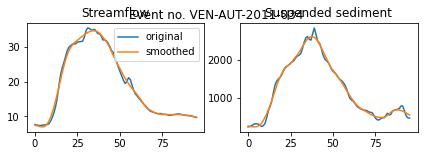

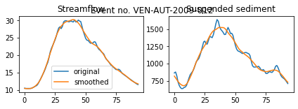

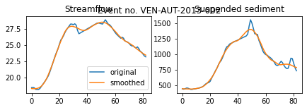

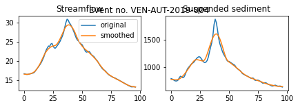

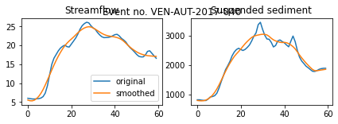

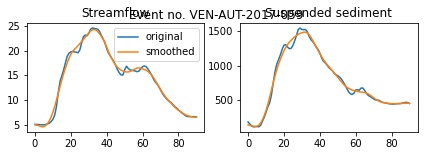

[8 more figures not shown]

```python
window_length, polyorder = (21, 3)

test_smoothing(test_events, window_length, polyorder)
```

#### Filter settings 2 from Javed et al.

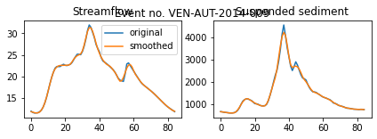

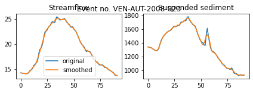

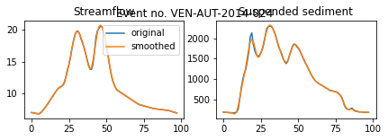

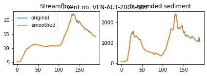

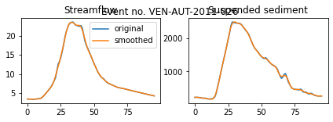

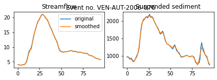

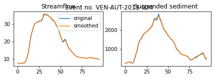

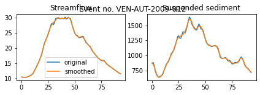

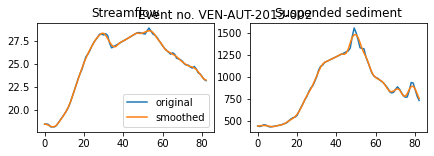

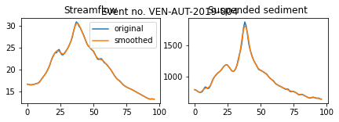

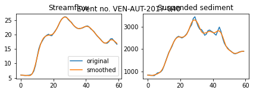

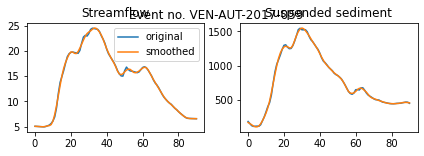

[8 more figures not shown]

```python
window_length, polyorder = (13, 4)

test_smoothing(test_events, window_length, polyorder)
```